# OBV2 Verdicts Notebook

# OBV2 Verdicts 1781-1880

Explore trial verdicts comparing presence of tagged speech and defendant speech.

This is the html output of an R Notebook. The underlying dataset is here. The R Markdown file from which it is generated is here. The chunks of R code can be hidden for convenience (to hide/show all at once click on the ‘’’Code’’’ button at the top of the page).

## About the data

Summary data about single-defendant Old Bailey Online trials 1780-1880 in sessions that have been tagged in the Old Bailey Corpus (v2). This includes OBO trial reference and session date; whether a trial report contains taggable direct speech; whether the defendant speaks in the trial; total word count; spoken word count; spoken word and utterance counts for the defendant; count of OBC-tagged ‘utterances’; counts of types of utterance for defendants; offence, verdict and sentence categories; defendant name, gender, age (if present) and occupation (as tagged, if present).

- Trials with multiple defendants have been excluded from the dataset because of the added complexity of matching them to utterances (and they aren’t always individually named).
- A few OBC sessions have been excluded from the dataset because of tagging issues.

## Some naming conventions

- tt = obc tagging type
  - tagged
  - untagged
- speech type
  - no_speech (equivalent to untagged)
  - deft_speaks
  - deft_silent
- vercat = obo verdict category
  - g = guilty
  - ng = not guilty
  - gng = guilty+not guilty (ie, excludes misc, special etc)

## R preliminaries

required packages, functions, etc

```r
# necessary packages
library(plyr)
library(dplyr)
library(tidyr)
library(ggplot2)
library(scales)
```

```r
# reusable non-data things + functions (ooh-err)
set_graphs_theme_ltop <- theme(legend.position = "top", axis.text=element_text(size=6), title=element_text(size=8), legend.title=element_text(size=8), legend.text=element_text(size=6), plot.title=element_text(size=16))
set_graphs_theme_g <- theme(axis.text=element_text(size=6), title=element_text(size=8), legend.title=element_text(size=8), legend.text=element_text(size=6), plot.title=element_text(size=16))
# Multiple plot function
#
# ggplot objects can be passed in ..., or to plotlist (as a list of ggplot objects)
# - cols:   Number of columns in layout
# - layout: A matrix specifying the layout. If present, 'cols' is ignored.
#
# If the layout is something like matrix(c(1,2,3,3), nrow=2, byrow=TRUE),
# then plot 1 will go in the upper left, 2 will go in the upper right, and
# 3 will go all the way across the bottom.
#
multiplot <- function(..., plotlist=NULL, file, cols=1, layout=NULL) {
  library(grid)

  # Make a list from the ... arguments and plotlist
  plots <- c(list(...), plotlist)

  numPlots = length(plots)

  # If layout is NULL, then use 'cols' to determine layout
  if (is.null(layout)) {
    # Make the panel
    # ncol: Number of columns of plots
    # nrow: Number of rows needed, calculated from # of cols
    layout <- matrix(seq(1, cols * ceiling(numPlots/cols)),
                     ncol = cols, nrow = ceiling(numPlots/cols))
  }

  if (numPlots==1) {
    print(plots[[1]])

  } else {
    # Set up the page
    grid.newpage()
    pushViewport(viewport(layout = grid.layout(nrow(layout), ncol(layout))))

    # Make each plot, in the correct location
    for (i in 1:numPlots) {
      # Get the i,j matrix positions of the regions that contain this subplot
      matchidx <- as.data.frame(which(layout == i, arr.ind = TRUE))

      print(plots[[i]], vp = viewport(layout.pos.row = matchidx$row,
                                      layout.pos.col = matchidx$col))
    }
  }
}
```

## Get the data

Get full data; filter to guilty/not guilty verdicts only, exclude 1784 (only one trial for entire year), remove 1780

full dataset in TSV file

```r
# read in the full data
obv2_defendants_trials <- read.table("obv_defendants_trials.tsv",
                   header=TRUE,
                   sep="\t")
### filter: guilty/not guilty verdicts only; exclude 1784 (single trial) and 1780
obv2_f_gng <- obv2_defendants_trials %>% filter(grepl('uilty',deft_vercat), year != 1784, year !=1780)
## add tt column for tagged/untagged trials (*requires plyr)
obv2_f_gng$tt <- revalue(obv2_f_gng$speech, c("deft_speaks"="tagged", "deft_silent"="tagged", "no_speech"="untagged"))
```

### Summarise data

Breakdowns (all by year +) by tagged type, speech type, verdict categories.

```r
### all trials
obv2_gng_year <- obv2_f_gng %>% select(year) %>% group_by(year) %>% summarise(n_trials = n())
### breakdown by tagged type
obv2_gng_year_tagged <- obv2_f_gng %>% select(year, tt) %>% group_by(year, tt) %>% summarise(n_tt = n())
### breakdown by speech type
obv2_gng_year_speech <- obv2_f_gng %>% select(year, speech) %>% group_by(year, speech) %>% summarise(n_speech = n())
# same but add tagged type column
obv2_gng_year_speech_tt <- obv2_f_gng %>% select(year, speech, tt) %>% group_by(year, speech, tt) %>% summarise(n_speech = n())
### breakdown by vercat
obv2_gng_year_vercat <- obv2_f_gng %>% select(year, deft_vercat) %>% group_by(year, deft_vercat) %>% summarise(n_vercat = n())
### breakdown by vercat and tagged type
obv2_gng_year_vercat_tt <- obv2_f_gng %>% select(year, deft_vercat, tt) %>% group_by(year, deft_vercat,tt) %>% summarise(n_vercat_tt = n())
### breakdown by speech type and vercat
obv2_gng_year_speech_vercat <- obv2_f_gng %>% select(year, speech, deft_vercat) %>% group_by(year, speech, deft_vercat) %>% summarise(n_speech_vercat = n())
```

## Visualisations

Start with comparisons of tagged/untagged trials and of speech types without verdict breakdowns.

### Stacked chart: count of tagged / untagged trials

1. area chart (smooths out gaps)

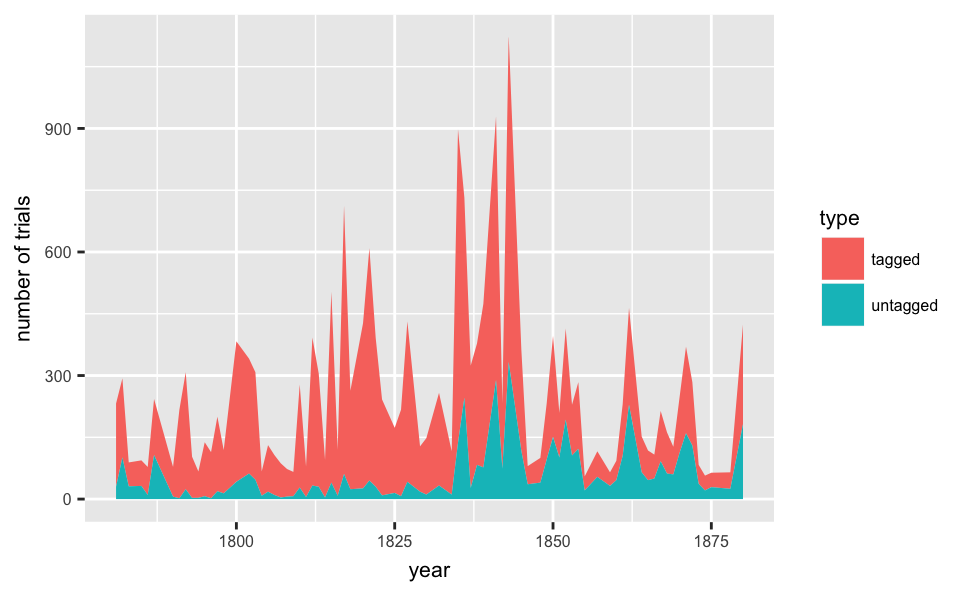

```r
ggplot(data=obv2_gng_year_tagged, aes(x=year,y=n_tt)) +
  geom_area(position="stack",stat='identity', aes(fill=tt)) +
  set_graphs_theme_g + labs(y="number of trials", fill="type")
```

2. bar chart

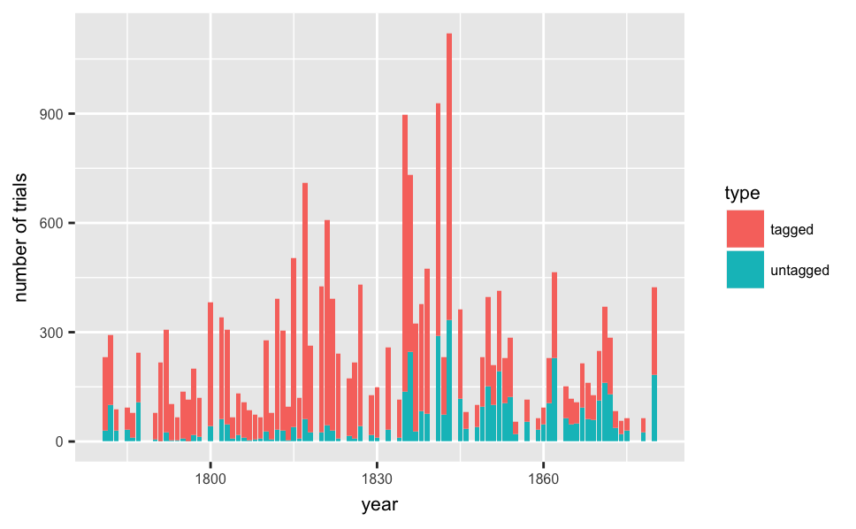

```r
ggplot(data=obv2_gng_year_tagged, aes(x=year, y=n_tt)) +
  geom_bar(position="stack",stat='identity', aes(fill=tt)) +
  set_graphs_theme_g + labs(y="number of trials", fill="type")
```

### Same data, unstacked

[corrected error, earlier version was using completely wrong data!]

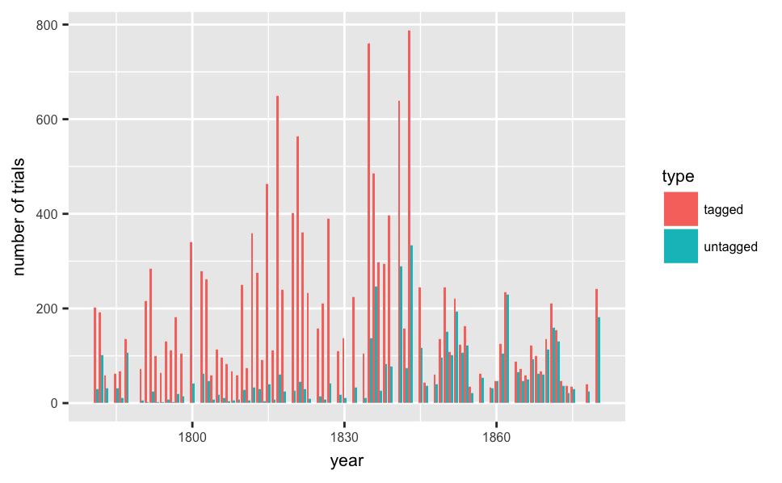

```r
ggplot(data=obv2_gng_year_tagged, aes(x=year, y=n_tt)) +
  geom_bar(position="dodge",stat='identity', aes(fill=tt)) +
  set_graphs_theme_g + labs(y="number of trials", fill="type")
```

### Stacked proportional chart: tagged / untagged trials

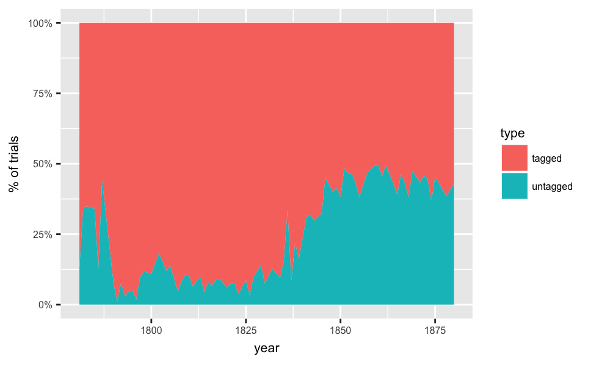

```r
# percent_format requires scales package
ggplot(obv2_gng_year_tagged, aes(x = year, y = n_tt)) +
  geom_area(position="fill",stat='identity', aes(fill = tt)) +
  scale_y_continuous(labels = percent_format()) +
  set_graphs_theme_g + labs(y="% of trials", fill="type")
```

### Stacked proportional chart: speech types (deft silent/deft speaks/no speech), all trials

(no_speech is exactly the same as untagged above)

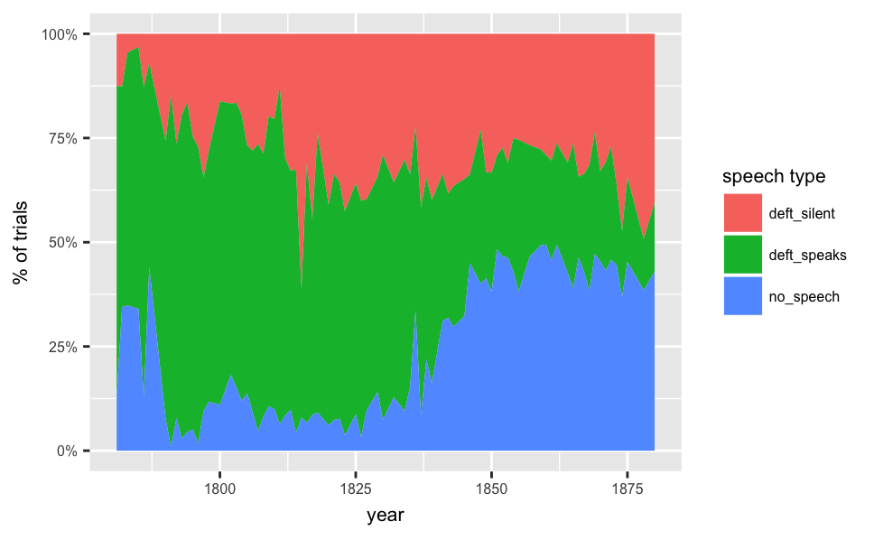

```r
# all trials: by speech types
ggplot(obv2_gng_year_speech,aes(x = year, y = n_speech)) +
  geom_area(position="fill",stat='identity', aes(fill = speech)) +
  scale_y_continuous(labels = percent_format()) +
  set_graphs_theme_g + labs(y="% of trials", fill="speech type")
```

### Stacked proportional chart: speech types, tagged trials only

removed untagged trials to compare defendant speaks / silent

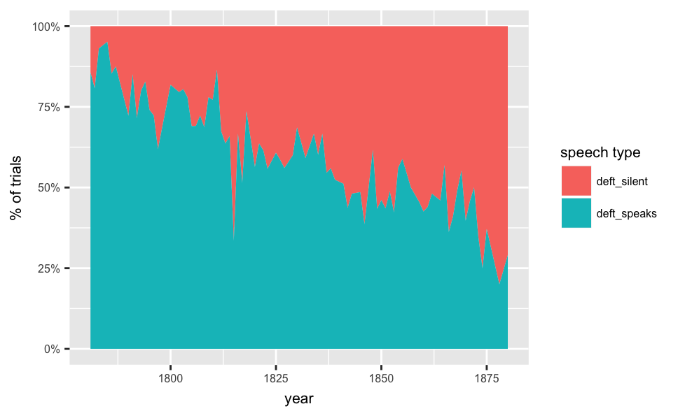

```r
obv2_gng_year_speech_tt %>% filter(tt=='tagged') %>%
  ggplot(aes(x = year, y = n_speech)) +
  geom_area(position="fill",stat='identity', aes(fill=speech)) +
  scale_y_continuous(labels = percent_format()) +
  set_graphs_theme_g + labs(y="% of trials", fill="speech type")
```

Bring in the verdicts

### Stacked chart: count of guilty/not guilty, all trials

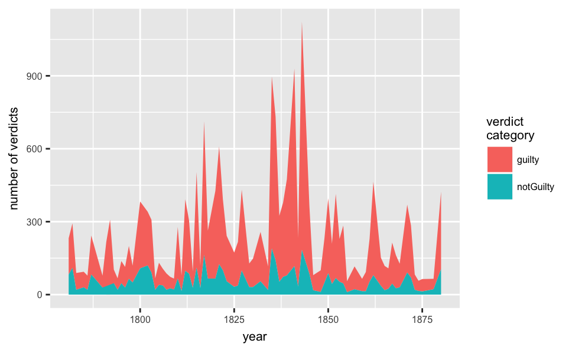

```r
ggplot(data=obv2_gng_year_vercat, aes(x=year,y=n_vercat)) +
  geom_area(position="stack",stat='identity', aes(fill=deft_vercat)) +
  set_graphs_theme_g +
  labs(y="number of verdicts", fill="verdict\ncategory")
```

Bar chart

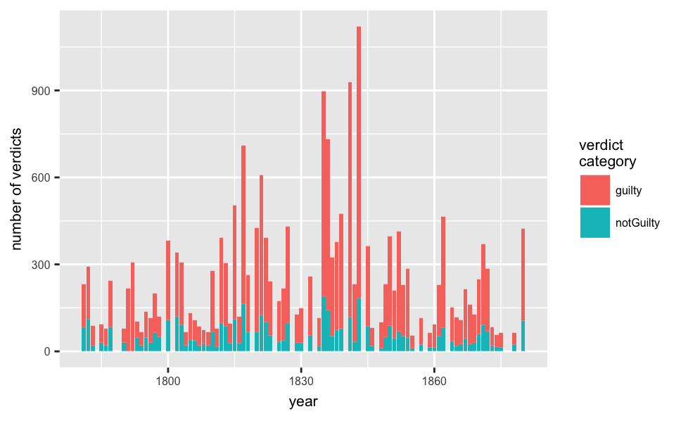

```r
ggplot(data=obv2_gng_year_vercat, aes(x=year,y=n_vercat)) +
  geom_bar(position="stack",stat='identity', aes(fill=deft_vercat)) +
  set_graphs_theme_g +
  labs(y="number of verdicts", fill="verdict\ncategory")
```

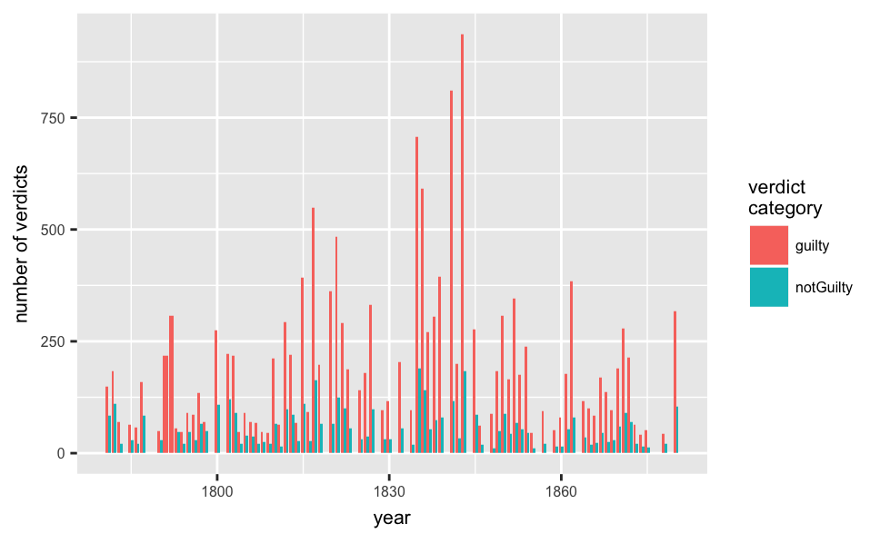

```r
ggplot(data=obv2_gng_year_vercat, aes(x=year,y=n_vercat)) +
  geom_bar(position="dodge",stat='identity', aes(fill=deft_vercat)) +
  set_graphs_theme_g +
  labs(y="number of verdicts", fill="verdict\ncategory")
```

### Stacked proportional chart: guilty/not guilty, all trials

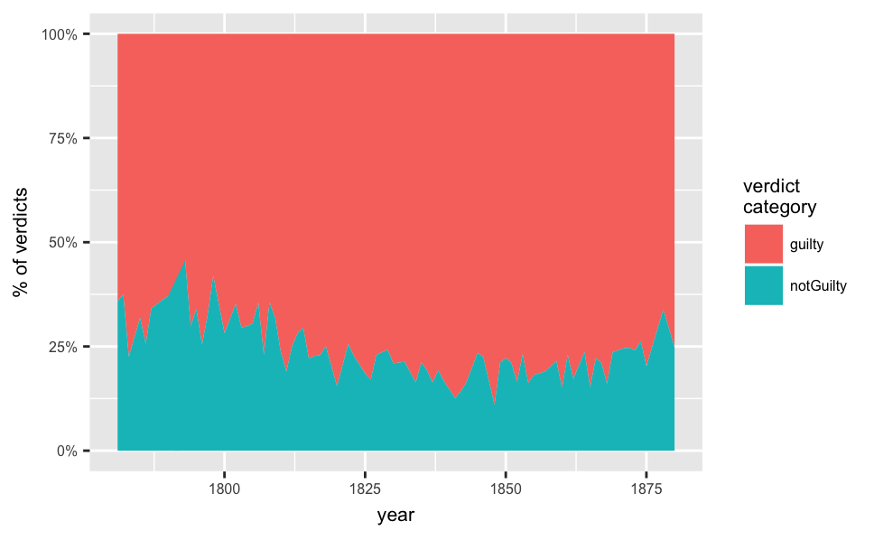

```r
ggplot(obv2_gng_year_vercat,aes(x = year, y = n_vercat)) +
  geom_area(position="fill",stat='identity', aes(fill=deft_vercat)) +
  scale_y_continuous(labels = percent_format()) +
  set_graphs_theme_g + labs(y="% of verdicts", fill="verdict\ncategory")
```

### We can compare normal stacked and proportional

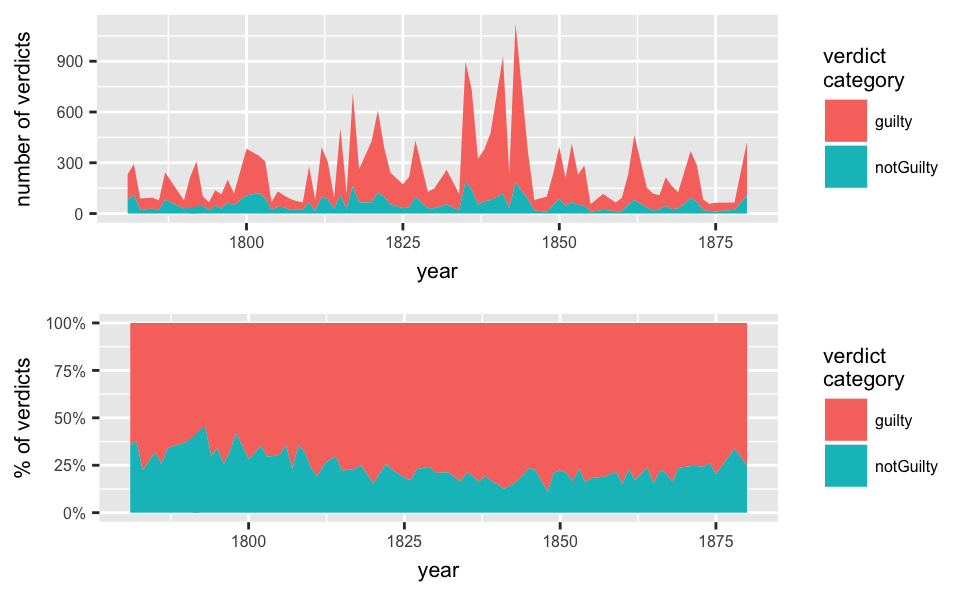

```r
multiplot(
  ggplot(data=obv2_gng_year_vercat, aes(x=year,y=n_vercat)) +
  geom_area(position="stack",stat='identity', aes(fill=deft_vercat)) +
  set_graphs_theme_g +
  theme(axis.title.y=element_text(margin=margin(0,10,0,0))) +
  labs(y="number of verdicts", fill="verdict\ncategory")
  ,
  ggplot(obv2_gng_year_vercat,aes(x = year, y = n_vercat)) +
  geom_area(position="fill",stat='identity', aes(fill=deft_vercat)) +
  scale_y_continuous(labels = percent_format()) +
  set_graphs_theme_g + labs(y="% of verdicts", fill="verdict\ncategory")
)
```

### Stacked proportional chart: guilty/not guilty verdicts, tagged trials only

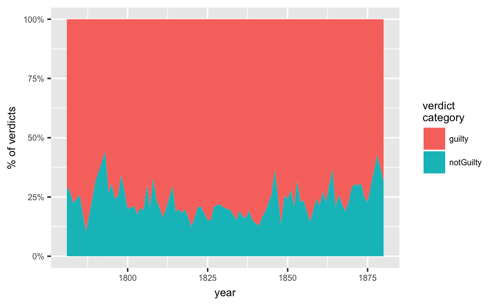

```r
obv2_gng_year_vercat_tt %>% filter(tt =='tagged') %>%
  ggplot(aes(x = year, y = n_vercat_tt)) +
  geom_area(position="fill",stat='identity', aes(fill=deft_vercat)) +
  scale_y_continuous(labels = percent_format()) +
  set_graphs_theme_g + labs(y="% of verdicts", fill="verdict\ncategory")
```

### Stacked proportional chart: guilty/not guilty verdicts, untagged trials only

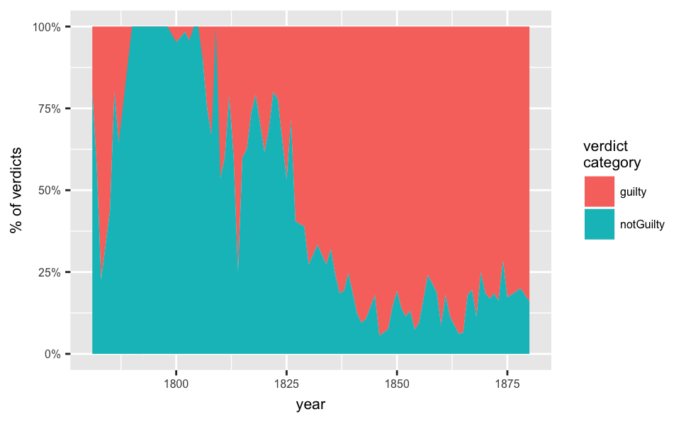

```r
# no_speech trials, guilty/not guilty
obv2_gng_year_vercat_tt %>% filter(tt =='untagged') %>%
  ggplot(aes(x = year, y = n_vercat_tt)) +
  geom_area(position="fill",stat='identity', aes(fill=deft_vercat)) +
  scale_y_continuous(labels = percent_format()) +
  set_graphs_theme_g + labs(y="% of verdicts", fill="verdict \ncategory")
```

### Stacked proportional chart: guilty/not guilty verdicts, defendant_speaks only

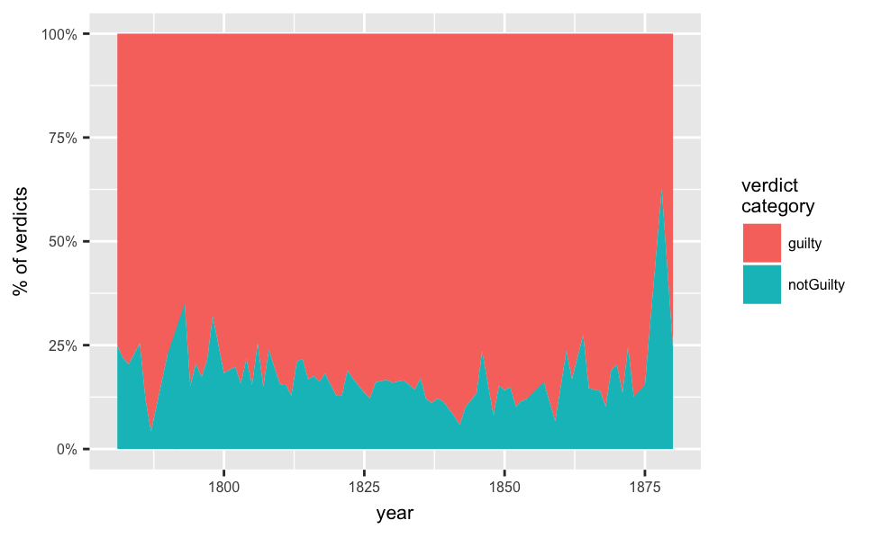

```r
obv2_gng_year_speech_vercat %>% filter(speech =='deft_speaks') %>%
  ggplot(aes(x = year, y = n_speech_vercat)) +
  geom_area(position="fill",stat='identity', aes(fill=deft_vercat)) +
  scale_y_continuous(labels = percent_format())  +
  set_graphs_theme_g + labs(y="% of verdicts", fill="verdict \ncategory")
```

### Stacked proportional chart: guilty/not guilty verdicts, deft_silent only

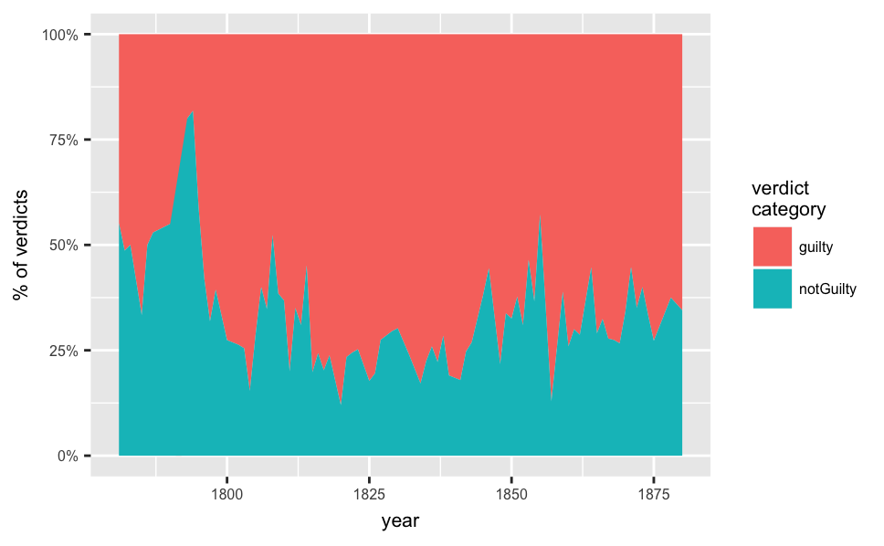

```r
# deft_silent trials only, guilty/not guilty
obv2_gng_year_speech_vercat %>% filter(speech =='deft_silent') %>%
  ggplot(aes(x = year, y = n_speech_vercat)) +
  geom_area(position="fill",stat='identity', aes(fill=deft_vercat)) +
  scale_y_continuous(labels = percent_format()) +
  set_graphs_theme_g + labs(y="% of verdicts", fill="verdict \ncategory")
```

### Compare guilty/not guilty for speech types

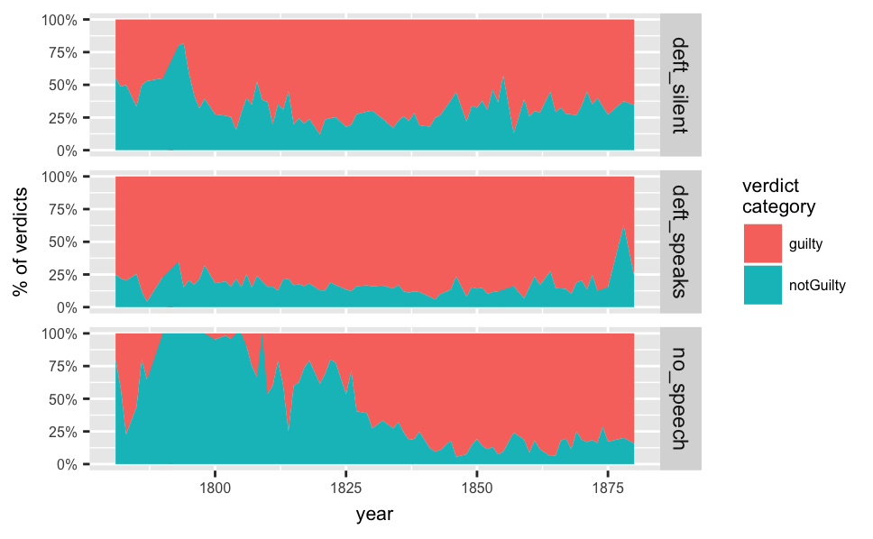

```r
ggplot(data=obv2_gng_year_speech_vercat,aes(x = year, y = n_speech_vercat)) +
  geom_area(position="fill",stat='identity', aes(fill=deft_vercat)) +
  scale_y_continuous(labels = percent_format()) +
  facet_grid(speech ~ .) +
  set_graphs_theme_g  + labs(y="% of verdicts", fill="verdict\ncategory")
```

### Compare tagged/untagged for guilty/not guilty verdicts

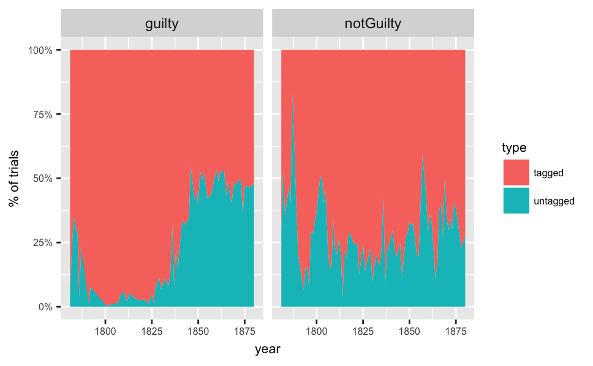

```r
ggplot(obv2_gng_year_vercat_tt, aes(x = year, y = n_vercat_tt)) +
  geom_area(position="fill",stat='identity', aes(fill=tt)) +
  scale_y_continuous(labels = percent_format()) +
  facet_grid(. ~ deft_vercat) +
  set_graphs_theme_g + labs(y="% of trials", fill="type")
```

or…

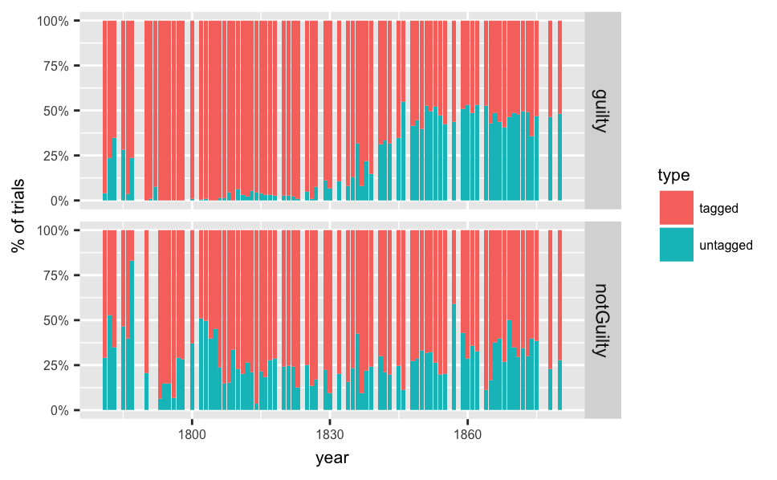

```r
ggplot(obv2_gng_year_vercat_tt, aes(x = year, y = n_vercat_tt)) +
  geom_bar(position="fill",stat='identity', aes(fill=tt)) +
  scale_y_continuous(labels = percent_format()) +
  facet_grid(deft_vercat~.) +
  set_graphs_theme_g + labs(y="% of trials", fill="type")
```

### Compare speech types for guilty/not guilty

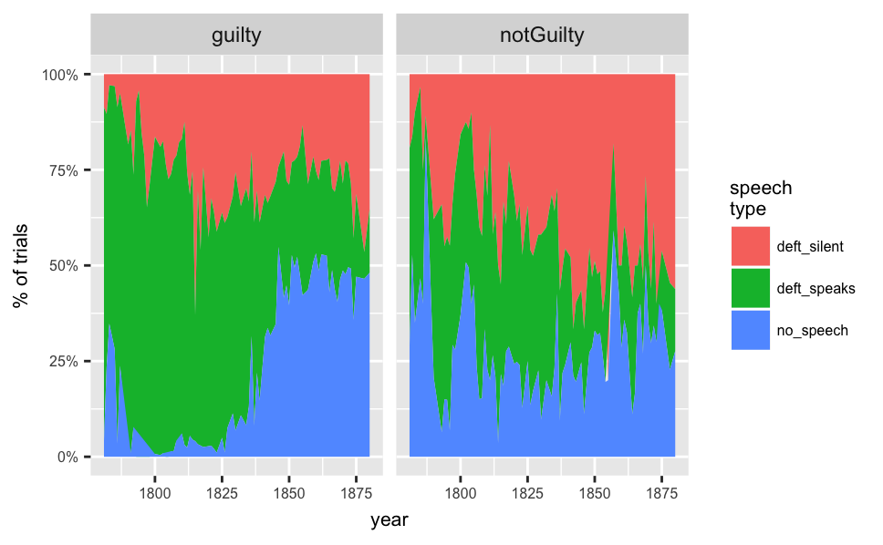

```r
ggplot(obv2_gng_year_speech_vercat,aes(x = year, y = n_speech_vercat)) +
  geom_area(position="fill",stat='identity', aes(fill=speech)) +
  scale_y_continuous(labels = percent_format()) +
  facet_grid(. ~ deft_vercat) +
  set_graphs_theme_g + labs(y="% of trials", fill="speech\ntype")
```

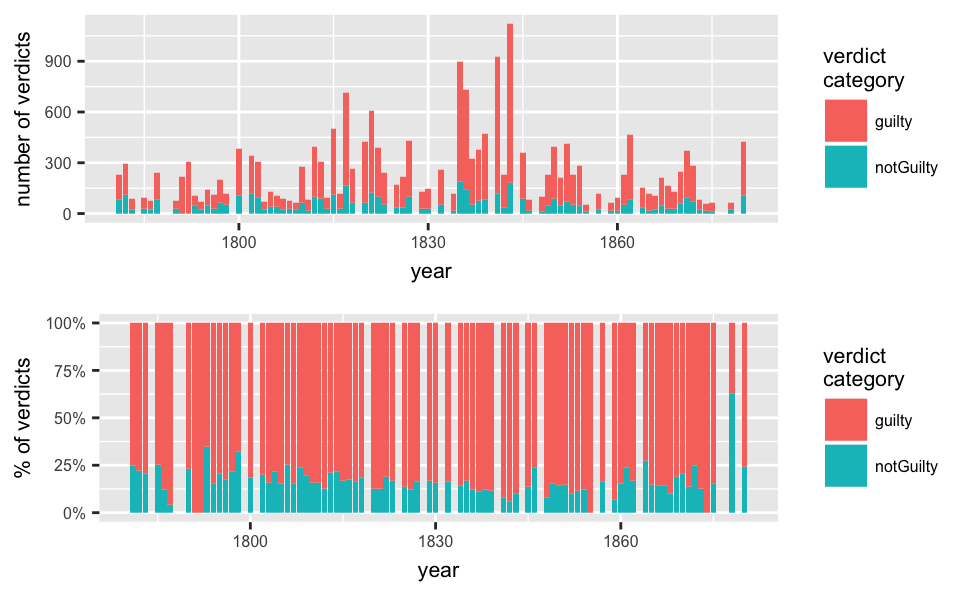

```r
multiplot(
ggplot(data=obv2_gng_year_vercat, aes(x=year,y=n_vercat)) +
  geom_bar(position="stack",stat='identity', aes(fill=deft_vercat)) +
  set_graphs_theme_g +
  labs(y="number of verdicts", fill="verdict\ncategory")
  ,
obv2_gng_year_speech_vercat %>% filter(speech =='deft_speaks') %>%
  ggplot(aes(x = year, y = n_speech_vercat)) +
  geom_bar(position="fill",stat='identity', aes(fill=deft_vercat)) +
  scale_y_continuous(labels = percent_format())  +
  set_graphs_theme_g + labs(y="% of verdicts", fill="verdict \ncategory")
)
```